# Project III: Data Visualization

# Submitted by Glory Edamkue

### Investigation Overview

In this investgation I looked at the employment status, loan amount, loan term and the rates (APR and DTI) relationship to it.

### Dataset Overview

I decided to work on the loan dataset from Prosper Loan. It contains the data of around 114,000 borrowers of the Prosper Loan company. The data set has data that could prove meaningful in understanding their loan setup and more about their borrowers.

### What is the structure of your dataset?

There are 113937 entries in the dataset representing borrowers of the loan company, Prosper Loan. The sliced dataset I will be working with has variables such as Annual Percentage Rate (APR), Debt to Income ratio (DTI), Employment Status, Occupation, Amount Delinquent, Income Verifiable, Stated Monthly Income, to mention a few. Most variables are numeric in nature, thugh there are categoric varaibles with numeric ordering. I do not consider the null values that significant to impact any exploration I would like to make, seeing that all are less than 10% of the dataset.

### What is/are the main feature(s) of interest in your dataset?

My interest lies in the income, term, Annual Percentage Rate (APR) and/or Debt To Income (DTI) ratio of borrowers. I would like to explore these relationships at a higher level in my bivariate explorations.

### What features in the dataset do you think will help support your investigation into your feature(s) of interest?

I feel all my interests are inter-related, but I do not know to what extent and if any other variables have an influence in it. For instance, I feel that the loan status could be affected by employment status, term, APR and the DTI of the borrower. And these variables could be in turn influenced by the state of the borrower due to things like income. I think that when the income is higher, that the APR reduces, and that the DTI is not influenced by any other variables save the delinquency of the borrower. Perhaps the employment status determines the DTI, and it is higher for unemployed people.I would like to see how true that is. I feel that those who take loans do not have high enough incomes, so I would like to know what the relationship between occupation and income is like.

### Explorations

### Bivariate Plots

I started off with a general overview of majority of the variables I would like to work with. Some are the borrower Annual Percentage Rate (APR), the Debt To Income (DTI) ratio, Stated Monthly Income, the Occupation, Borrower State, and a few others, in order to gain meaningful insights. I will also include some other variables that I have not explored until now.

#### General overview of variables explored

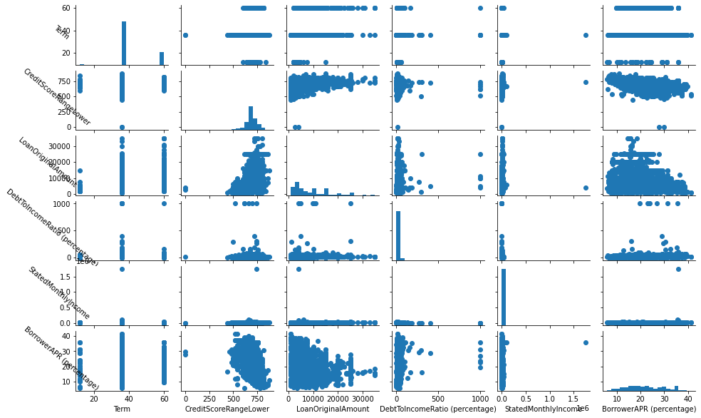

#### Observation(s):

The debt to income ratio versus the original loan amount is slightly skewed to the right. It seems to reduce with an increase in the loan amount. It will be interesting to see what affects that observation.

More credit ranges seem to lie in the 36 month term of loans, that also seems to be the most popular loan term.

The original loan amount and the credit range looks like it could increase in the middlemost credit score range. The credit range appears to be higher for higher loan amounts.

#### Amount delinquent and its relationship with the stated monthly income

##### What income category of borrowers are likely to be more delinquent? To what extent is their delinquency?

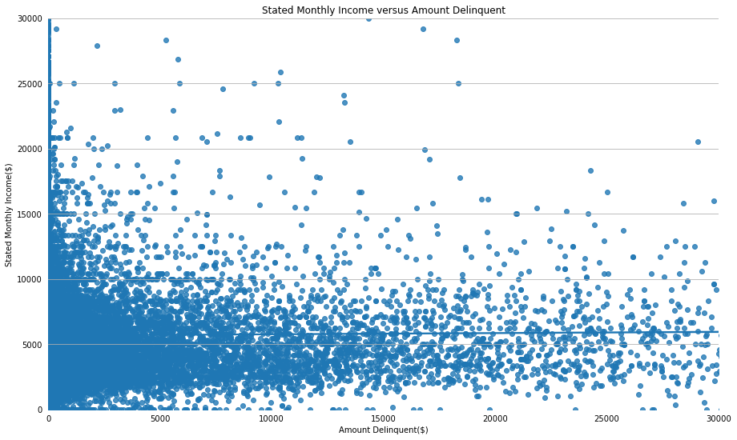

#### DTI, APR and the effect of loan term

Are those with more income given longer loan terms and lower borrower rates and higher loan amounts? How about those with different employment stauses?

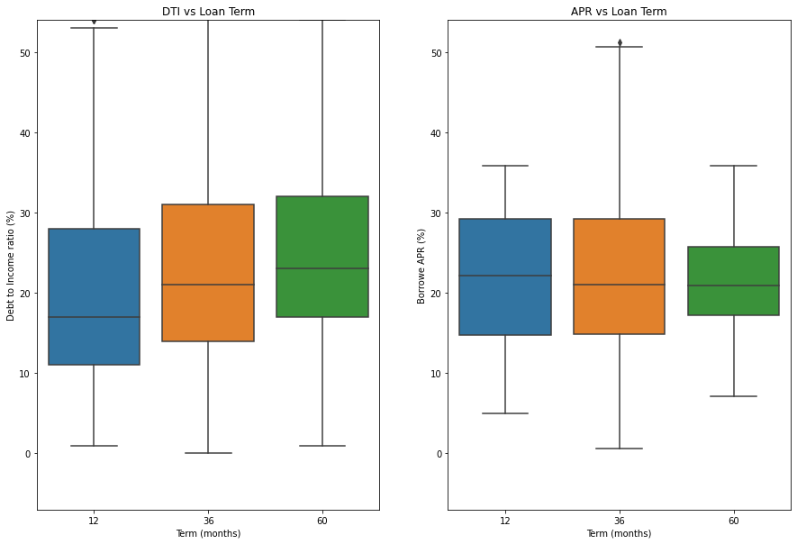

| Term | DebtToIncomeRatio (percentage) count | DebtToIncomeRatio (percentage) mean | DebtToIncomeRatio (percentage) std | DebtToIncomeRatio (percentage) min | DebtToIncomeRatio (percentage) 25% | DebtToIncomeRatio (percentage) 50% | DebtToIncomeRatio (percentage) 75% | DebtToIncomeRatio (percentage) max | BorrowerAPR (percentage) count | BorrowerAPR (percentage) mean | BorrowerAPR (percentage) std | BorrowerAPR (percentage) min | BorrowerAPR (percentage) 25% | BorrowerAPR (percentage) 50% | BorrowerAPR (percentage) 75% | BorrowerAPR (percentage) max |
| --- | --- | --- | --- | --- | --- | --- | --- | --- | --- | --- | --- | --- | --- | --- | --- | --- |
| 12 | 1415.0 | 22.024735 | 31.186646 | 1.0 | 11.0 | 17.0 | 28.0 | 1001.0 | 1614.0 | 21.622322 | 9.023572 | 4.935 | 14.7165 | 22.189 | 29.167 | 35.843 |
| 36 | 80825.0 | 28.250345 | 61.438437 | 0.0 | 14.0 | 21.0 | 31.0 | 1001.0 | 87753.0 | 21.943081 | 8.548865 | 0.653 | 14.8570 | 20.976 | 29.265 | 51.229 |
| 60 | 23143.0 | 25.645292 | 24.767521 | 1.0 | 17.0 | 23.0 | 32.0 | 1001.0 | 24545.0 | 21.684251 | 5.747886 | 7.111 | 17.1840 | 20.931 | 25.718 | 35.838 |

##### Observation(s):

From observing the medians of both sets of box plots (as well as other quartiles), it is safe to say that DTI increases with the loan term, while APR decreases with increase in the loan term, though marginally.

#### Loan status and borrower API

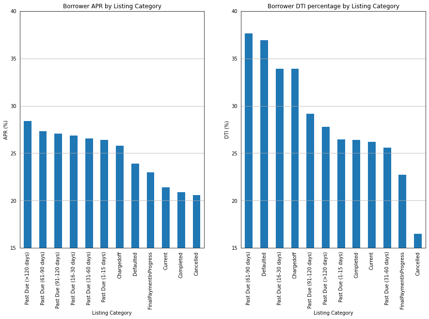

##### Observation(s):

I have decided to go with using the median values to evaluate the plots.

Those who have payments due past 120 days have the highest APR % median value, and that could have affected their ability to repay the loans. Likewise those with charged off loans.

#### What is the monetary aspect of the dataset?

##### Does the income affect the average DTI ratio or borrowers annual percentage rate? What about the relationship between owed payments?

#### Average income and loan term

##### What is the average income of each loan term category?

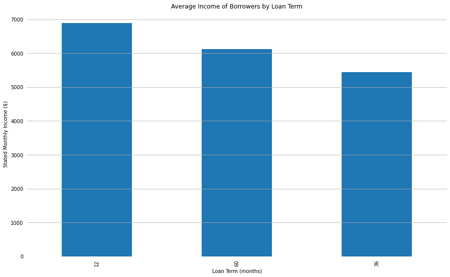

#### Loan original amount and term

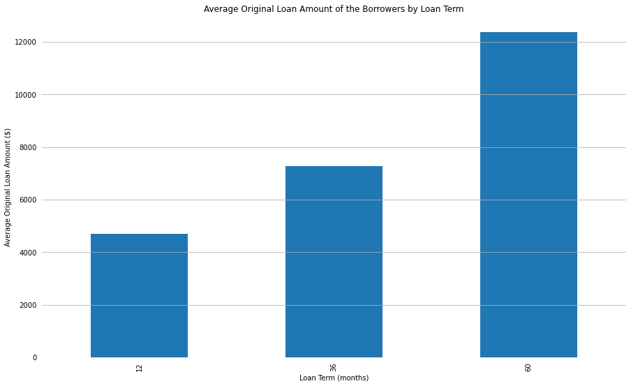

### Multivariate Plots

#### Debt to income ratio versus borrower APR and loan term

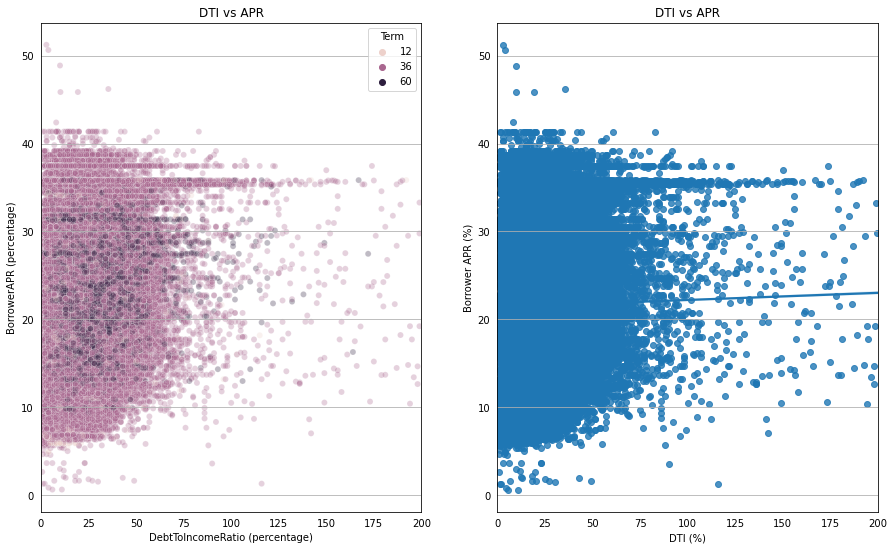

#### Income versus other variables that could have a possible effect on it

#### Income and Borrower APR

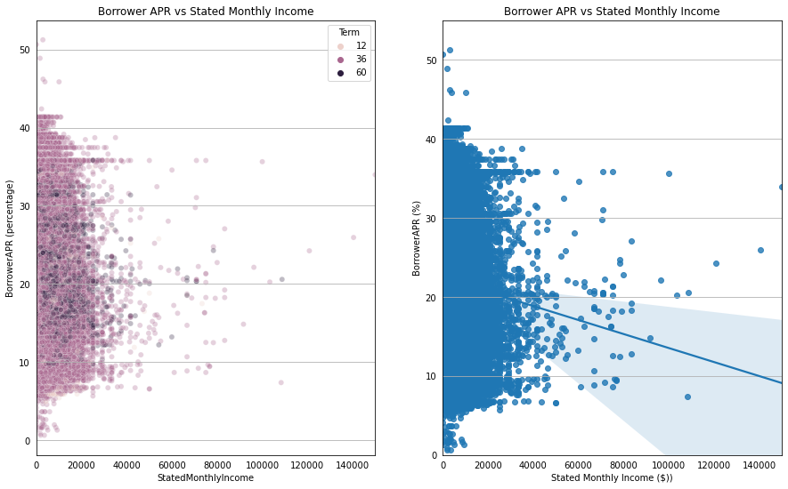

##### Observations(s):

The greatest APR frequency lies between 10 - 35%.The APR is relatively static irregardless of income, though the higher your income the lower your APR could be, and the lower your income the higher your APR.

#### Credit range scores and APR

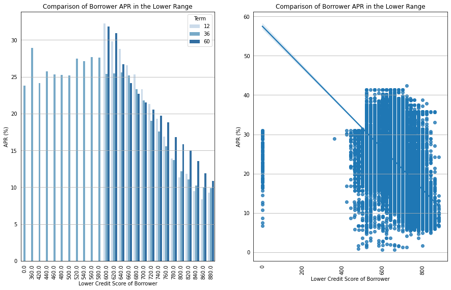

##### Observation(s):

It is likely that the credit score is the determinant of APR percentage for borrowers.

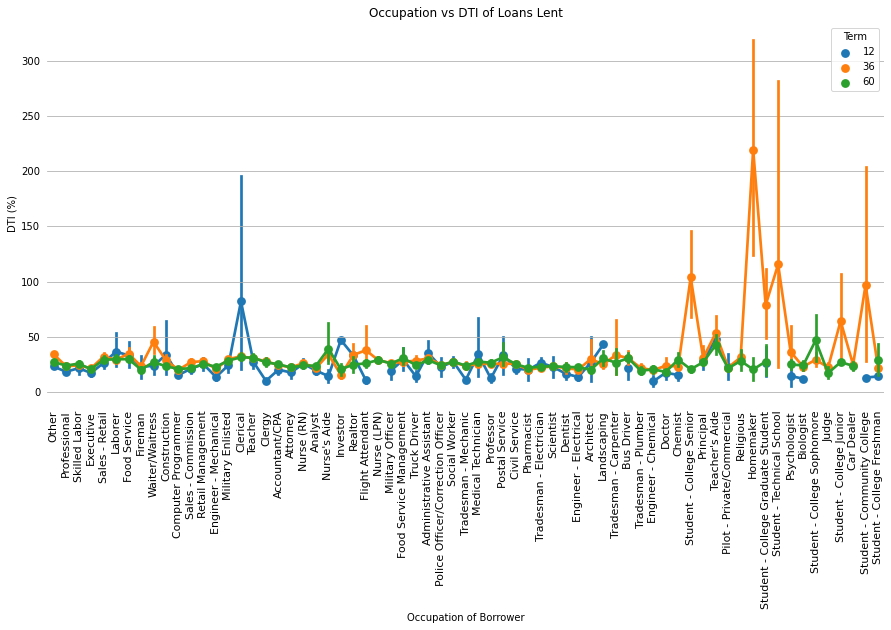

##### Observation:

Certain borrowers appear to be in debt of loans. The notably indebted ones are students of technical schools, college graduate students and homemakers, despite loan terms of 36 months. One would be cautious of giving loans to students and homemakers as the bulk of their income goes into servicing loans.

### Were there any interesting or surprising interactions between features?

People who need loans to get a move on in life tend to be more likely to be delinquent and need larger loans. They were indebted from previous unpaid due payments, and will likely spend time paying off loans that are past their due date. This means a lot of them are actually living in debt.

I was equally suprised that people would take out a loan to pay another loan, and the loan company was not cautious of that fact. Or taking loans to pay taxes.